# E-commerce Exploratory Analytics & Dashboard

# 3 Question 2. Can we segment customers based on their purchasing behavior?

#RFM Segmentation

```r
rfm_data <- ecommerce_data %>%
  group_by(CustomerID) %>%
  summarize(
    Recency = as.numeric(difftime(max(Date), max(InvoiceDate), units = "days")),  # Days since last purchase
    Frequency = n_distinct(InvoiceNo),  # Number of unique transactions
    Monetary = sum(Revenue, na.rm = TRUE)  # Total revenue per customer
  )
```

#Segment customers using quantiles

```r
rfm_data <- rfm_data %>%
  mutate(
    RecencySegment = ntile(-Recency, 4),  # Lower Recency is better, invert it
    FrequencySegment = ntile(Frequency, 4),
    MonetarySegment = ntile(Monetary, 4)
  )
```

#Combine segments into RFM Score

```r
rfm_data <- rfm_data %>%
  mutate(RFM_Score = RecencySegment + FrequencySegment + MonetarySegment)
```

#View segmented data

```r
print(head(rfm_data))
```

```
## # A tibble: 6 × 8
##   CustomerID Recency Frequency Monetary RecencySegment FrequencySegment
##        <dbl>   <dbl>     <int>    <dbl>          <int>            <int>
## 1      12346  -0.428         2       0               1                2
## 2      12347  -0.661         7    4310               4                4
## 3      12348  -0.551         4    1797.              3                3
## 4      12349  -0.410         1    1758.              1                1
## 5      12350  -0.667         1     334.              4                1
## 6      12352  -0.609        11    1545.              3                4
## # ℹ 2 more variables: MonetarySegment <int>, RFM_Score <int>
```

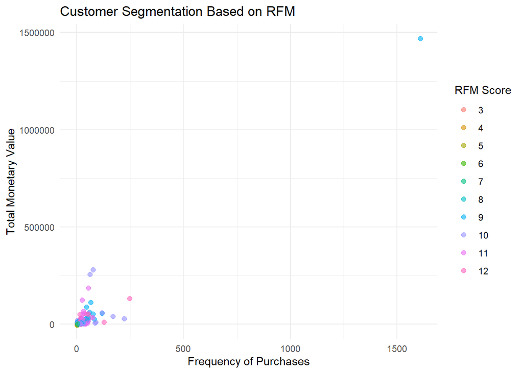

```r
ggplot(rfm_data, aes(x = Frequency, y = Monetary, color = as.factor(RFM_Score))) +
  geom_point(size = 2, alpha = 0.6) +
  labs(
    title = "Customer Segmentation Based on RFM",
    x = "Frequency of Purchases",
    y = "Total Monetary Value",
    color = "RFM Score"
  ) +
  theme_minimal()
```

#Extract top 100 customers based on RFM Score

```r
top_100_customers <- rfm_data %>%
  arrange(desc(RFM_Score)) %>%  # Sort by descending RFM Score
  head(100)
```

#Select top 100 customers

### 3.0.1 View the results of top and bottom 100

```r
print(top_100_customers)
```

```
## # A tibble: 100 × 8
##    CustomerID Recency Frequency Monetary RecencySegment FrequencySegment
##         <dbl>   <dbl>     <int>    <dbl>          <int>            <int>
##  1      12347  -0.661         7    4310               4                4
##  2      12362  -0.653        13    5155.              4                4
##  3      12455  -0.647         6    2467.              4                4
##  4      12471  -0.655        49   18706.              4                4
##  5      12483  -0.710        13    2327.              4                4
##  6      12490  -0.672        10    5418.              4                4
##  7      12500  -0.681        13    4206.              4                4
##  8      12520  -0.641         6    2583.              4                4
##  9      12524  -0.647         8    4486.              4                4
## 10      12553  -0.693        14    3652.              4                4
## # ℹ 90 more rows
## # ℹ 2 more variables: MonetarySegment <int>, RFM_Score <int>
```

```r
bottom_100_customers <- rfm_data %>%
  arrange(RFM_Score) %>%  # Sort by ascending RFM Score
  head(100)  # Select bottom 100 customers

# View the results
print(bottom_100_customers)
```

```
## # A tibble: 100 × 8
##    CustomerID Recency Frequency Monetary RecencySegment FrequencySegment
##         <dbl>   <dbl>     <int>    <dbl>          <int>            <int>
##  1      12441  -0.448         1    174.               1                1
##  2      12506  -0.371         1     73.5              1                1
##  3      12531  -0.467         1    125.               1                1
##  4      12574  -0.389         1    218.               1                1
##  5      12581  -0.372         1    198.               1                1
##  6      12602  -0.474         1    153.               1                1
##  7      12618  -0.465         1    177.               1                1
##  8      12672  -0.389         1    226.               1                1
##  9      12686  -0.410         1     89.1              1                1
## 10      12702  -0.442         1    219                1                1
## # ℹ 90 more rows
## # ℹ 2 more variables: MonetarySegment <int>, RFM_Score <int>
```

### 3.0.2 Question 3. Are there specific countries that contribute more to sales or have unique buying patterns?

```r
country_sales <- ecommerce_data %>%
  group_by(Country) %>%
  summarize(
    TotalRevenue = sum(Revenue, na.rm = TRUE),
    TotalTransactions = n_distinct(InvoiceNo),
    AverageOrderValue = TotalRevenue / TotalTransactions
  ) %>%
  arrange(desc(TotalRevenue))  # Sort by TotalRevenue in descending order

#View the top countries by revenue
print(head(country_sales, 10))
```

```
## # A tibble: 10 × 4
##    Country        TotalRevenue TotalTransactions AverageOrderValue
##    <chr>                 <dbl>             <int>             <dbl>
##  1 United Kingdom     8189252.             21391              383.
##  2 Netherlands         284662.               100             2847.
##  3 EIRE                262993.               360              731.
##  4 Germany             221509.               603              367.
##  5 France              197317.               461              428.
##  6 Australia           137010.                69             1986.
##  7 Switzerland          56363.                74              762.
##  8 Spain                54756.               105              521.
##  9 Belgium              40911.               119              344.
## 10 Sweden               36585.                46              795.
```

```r
#Select top 10 countries by revenue
top_countries <- country_sales %>%
  top_n(10, TotalRevenue)
```

### 3.0.3 Bar plot for top 10 countries

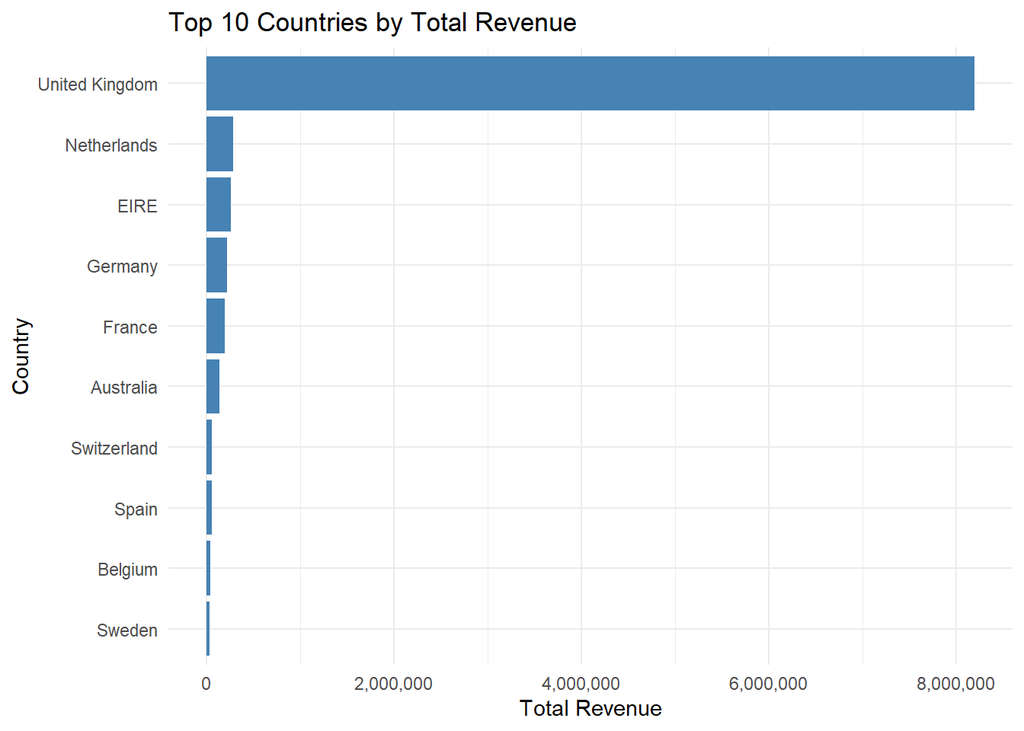

```r
ggplot(top_countries, aes(x = reorder(Country, TotalRevenue), y = TotalRevenue)) +
  geom_bar(stat = "identity", fill = "steelblue") +
  labs(
    title = "Top 10 Countries by Total Revenue",
    x = "Country",
    y = "Total Revenue"
  ) +
  scale_y_continuous(labels = scales::comma) +
  theme_minimal() +
  coord_flip()  # Flip coordinates for better readability
```

### 3.0.4 Bar plot for Average Order Value (Top 10 countries)

This plot helps identify countries with higher spending per transaction, which can indicate premium markets. For example, while a country may not contribute the most revenue overall, a high Average Order Value suggests opportunities for targeting premium customers or specialized marketing campaigns.

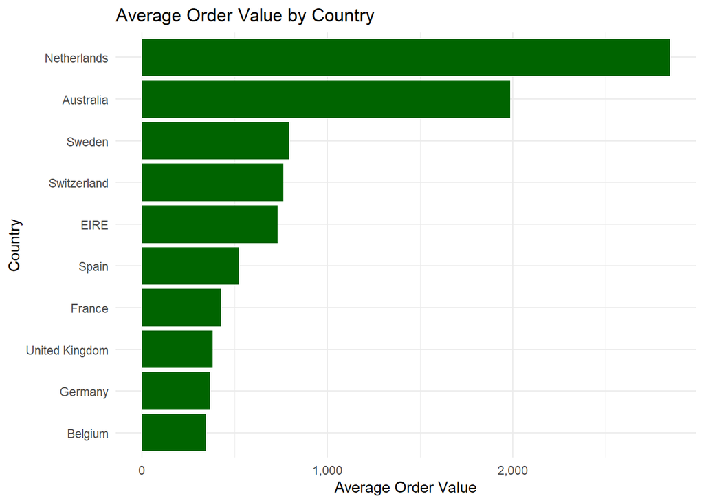

```r
ggplot(top_countries, aes(x = reorder(Country, AverageOrderValue), y = AverageOrderValue)) +
  geom_bar(stat = "identity", fill = "darkgreen") +
  labs(
    title = "Average Order Value by Country",
    x = "Country",
    y = "Average Order Value"
  ) +
  scale_y_continuous(labels = scales::comma) +
  theme_minimal() +
  coord_flip()
```

### 3.0.5 Question 4 (Bonus). How do cancellations impact overall sales trends?

#Identify and filter

```r
cancellations <- ecommerce_data %>%
  filter(Quantity < 0)

#Summarize cancellations by revenue and transactions
monthly_cancellations <- cancellations %>%
  group_by(Month = floor_date(InvoiceDate, "month")) %>%
  summarize(
    CancelledRevenue = abs(sum(Revenue, na.rm = TRUE)),  # Absolute value for revenue lost
    TotalCancelledTransactions = n()  # Count the number of canceled transactions
  )

#Check the class of the Month variable
class(monthly_cancellations$Month)  # Check class (should ideally return "Date")
```

```
## [1] "POSIXct" "POSIXt"
```

```r
#Convert Month to Date (if needed)
monthly_cancellations <- monthly_cancellations %>%
  mutate(Month = as.Date(Month))

#Verify the conversion
str(monthly_cancellations$Month)  # Should return "Date"
```

```
##  Date[1:13], format: "2010-12-01" "2011-01-01" "2011-02-01" "2011-03-01" "2011-04-01" ...
```

###Visualize monthly revenue loss due to cancellations

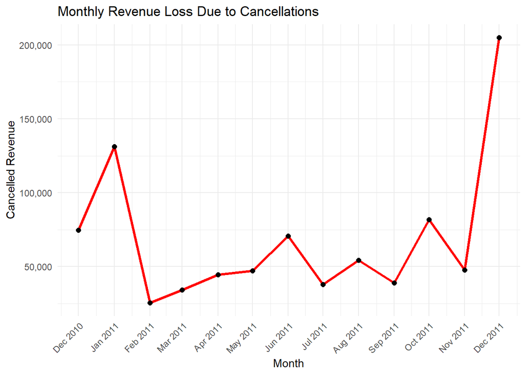

```r
ggplot(monthly_cancellations, aes(x = Month, y = CancelledRevenue)) +
  geom_line(color = "red", size = 1.2) +
  geom_point(size = 2) +
  labs(
    title = "Monthly Revenue Loss Due to Cancellations",
    x = "Month",
    y = "Cancelled Revenue"
  ) +
  scale_x_date(date_labels = "%b %Y", date_breaks = "1 month") +
  scale_y_continuous(labels = scales::comma) +
  theme_minimal() +
  theme(axis.text.x = element_text(angle = 45, hjust = 1))
```

###Compare cancellations to total revenue

```r
total_revenue <- sum(ecommerce_data$Revenue, na.rm = TRUE)

###Calculate percentage of revenue lost to cancellations
percentage_lost <- (sum(monthly_cancellations$CancelledRevenue) / total_revenue) * 100
cat("Percentage of revenue lost to cancellations:", round(percentage_lost, 2), "%\n")
```

```
## Percentage of revenue lost to cancellations: 9.17 %
```

```r
###Identify the most cancelled products
most_cancelled_products <- cancellations %>%
  group_by(Description) %>%
  summarize(
    CancelledQuantity = abs(sum(Quantity, na.rm = TRUE)),
    CancelledRevenue = abs(sum(Revenue, na.rm = TRUE))
  ) %>%
  arrange(desc(CancelledRevenue)) %>%
  head(10)

###View the most cancelled products
print(most_cancelled_products)
```

```
## # A tibble: 10 × 3
##    Description                        CancelledQuantity CancelledRevenue
##    <chr>                                          <dbl>            <dbl>
##  1 AMAZON FEE                                        32          235282.
##  2 PAPER CRAFT , LITTLE BIRDIE                    80995          168470.
##  3 Manual                                          4066          146784.
##  4 MEDIUM CERAMIC TOP STORAGE JAR                 74494           77480.
##  5 POSTAGE                                          147           11871.
##  6 REGENCY CAKESTAND 3 TIER                         855            9697.
##  7 CRUK Commission                                   16            7933.
##  8 Bank Charges                                      25            7341.
##  9 WHITE HANGING HEART T-LIGHT HOLDER              2578            6624.
## 10 FAIRY CAKE FLANNEL ASSORTED COLOUR              3150            6591.
```

### 3.0.6 Bar plot for revenue loss due to cancelled products

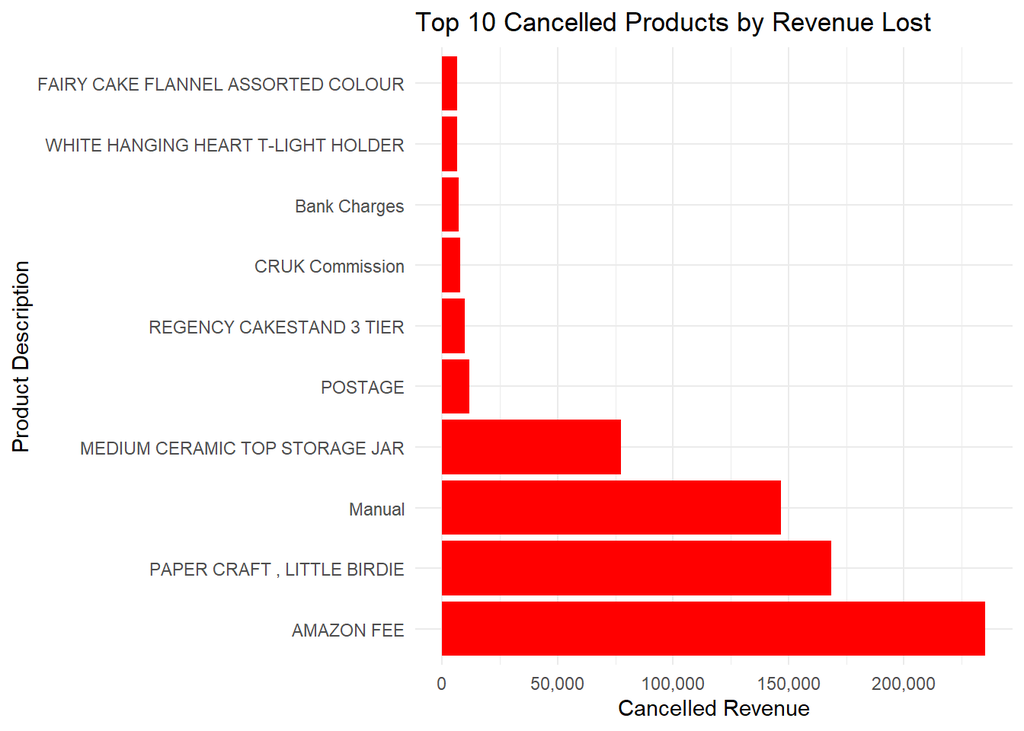

```r
ggplot(most_cancelled_products, aes(x = reorder(Description, -CancelledRevenue), y = CancelledRevenue)) +
  geom_bar(stat = "identity", fill = "red") +
  labs(
    title = "Top 10 Cancelled Products by Revenue Lost",
    x = "Product Description",
    y = "Cancelled Revenue"
  ) +
  scale_y_continuous(labels = scales::comma) +
  theme_minimal() +
  coord_flip()
```